# Coyne Lab iPSC patients FULL ORGANELLOMICS Preprocessing QC statistics

### Aug 2025 (new pre-processing) Nancy

- No Brenner cut offs used,
- Remove empty DAPI and marker tiles: dapi_max_intensity_threshold = marker_max_intensity_threshold = 0.2, dapi_variance_threshold = 0.03 and marker_variance_threshold = 0.0001.
- Removing dead cells blobs with MIN_ALIVE_NUCLEI_AREA = -1 and MIN_MEDIAN_INTENSITY_NUCLEI_BLOB_THRESHOLD = 0.8 (instead of the default 0.95)

Reran by Sagy on Sep 16 (2025) - removing CD41

```python
import io
import os
import sys
import contextlib
import pandas as pd
import seaborn as sns
from IPython.display import display, Javascript

NOVA_HOME = '/home/projects/hornsteinlab/Collaboration/NOVA'
NOVA_DATA_HOME = '/home/projects/hornsteinlab/Collaboration/NOVA'
os.environ['NOVA_HOME'] = NOVA_HOME
sys.path.insert(1, os.getenv("NOVA_HOME"))
print(f"NOVA_HOME: {os.getenv('NOVA_HOME')}")


root_directory_raw = os.path.join(NOVA_DATA_HOME, 'input', 'images', 'raw', 'AlyssaCoyne_new_sorted')
root_directory_proc = os.path.join(NOVA_DATA_HOME, 'input', 'images', 'processed', 'ManuscriptFinalData_80pct','AlyssaCoyne_new')

LOGS_PATH = os.path.join(NOVA_HOME, "outputs", "preprocessing", "ManuscriptFinalData_80pct", "AlyssaCoyne_new", "batch1/logs")
PLOT_PATH = os.path.join(NOVA_HOME, 'outputs', 'preprocessing', "ManuscriptFinalData_80pct", 'AlyssaCoyne_new', 'QC_figures')

os.chdir(NOVA_HOME)


from tools.preprocessing_tools.qc_reports.qc_utils import log_files_qc, run_validate_folder_structure, display_diff, sample_and_calc_variance, \
                                                show_site_survival_dapi_brenner, show_site_survival_dapi_cellpose, \
                                                show_site_survival_dapi_tiling, show_site_survival_target_brenner, \
                                                calc_total_sums, plot_filtering_heatmap, show_total_sum_tables, \
                                                plot_cell_count, plot_catplot, plot_hm_combine_batches, \
                                                run_calc_hist_new,plot_hm_of_mean_cell_count_per_tile

from tools.preprocessing_tools.qc_reports.qc_config import AC_panels_new, AC_markers_new, AC_marker_info_new, AC_cell_lines_new, AC_cell_lines_to_cond_new,\
                                    AC_cell_lines_for_disp_new, AC_reps_new, AC_line_colors_new, AC_lines_order_new, AC_custom_palette_new,\
                                    AC_expected_dapi_raw_new
%load_ext autoreload
%autoreload 2
```

```
NOVA_HOME: /home/projects/hornsteinlab/Collaboration/NOVA
```

```python
df = log_files_qc(LOGS_PATH)
df_dapi = df[df.marker=='DAPI']
df_target = df[df.marker!='DAPI']
```

```
reading logs of batch1

Total of 1 files were read.
Before dup handeling  (5286, 21)
After duplication removal #1: (5286, 22)
After duplication removal #2: (5286, 22)
```

```python
# choose batches
batches = ['batch1']
batches
```

```
['batch1']
```

## Actual Files Validation

### Raw Files Validation

1. How many site **tiff** files do we have in each folder?
2. Are all existing files valid? (tif, at least 2049kB, not corrupetd)

```
batch1
Folder structure is valid.
No bad files are found.
Total Sites:  5166
df_reset (64, 13) colored_df (64, 13)
             Rep C9\nCS2YNL C9\nCS8RFT Ctrl\nEDi029 SALSNegative\nCS0ANK  \
Marker
ANXA11      rep1          5          5            5                    5
ANXA11      rep2          5          5            5                    5
DCP1A       rep1          5          5            5                    5
DCP1A       rep2          5          5            5                    5
FUS         rep1          5          5            5                    5
...          ...        ...        ...          ...                  ...
TDP43       rep2          5          5            5                    5
Phalloidin  rep1          5          5            5                    5
Phalloidin  rep2          5          5            5                    5
DAPI        rep1         60         60           60                   60
DAPI        rep2         62         60           60                   60

           SALSNegative\nCS6ZU8 SALSPositive\nCS4ZCD C9\nCS7VCZ Ctrl\nEDi022  \
Marker
ANXA11                        5                    5          5            5
ANXA11                        5                    5          5            5
DCP1A                         5                    5          5            5
DCP1A                         5                    5          5            5
FUS                           5                    5          5            5
...                         ...                  ...        ...          ...
TDP43                         5                    5          5            5
Phalloidin                    5                    5          5            5
Phalloidin                    5                    5          5            5
DAPI                         60                   60         60           60
DAPI                         60                   60         60           60

           Ctrl\nEDi037 SALSNegative\nCS0JPP SALSPositive\nCS2FN3  \
Marker
ANXA11                5                    5                    5
ANXA11                5                    5                    5
DCP1A                 5                    5                    5
DCP1A                 5                    5                    5
FUS                   5                    5                    5
...                 ...                  ...                  ...
TDP43                 5                    5                    5
Phalloidin            5                    5                    5
Phalloidin            5                    5                    5
DAPI                 60                   60                   60
DAPI                 60                   60                   60

           SALSPositive\nCS7TN6
Marker
ANXA11                        5
ANXA11                        5
DCP1A                         5
DCP1A                         5
FUS                           5
...                         ...
TDP43                         5
Phalloidin                    5
Phalloidin                    5
DAPI                         60
DAPI                         60

[64 rows x 13 columns]
```

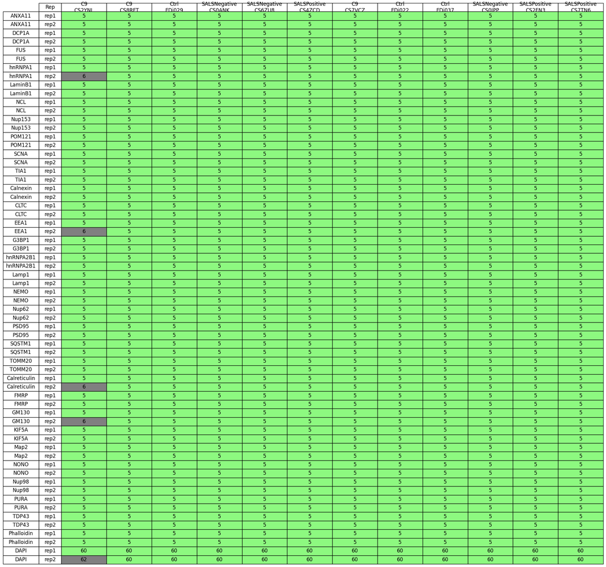

```python
raws = run_validate_folder_structure(root_directory_raw,
                                     False,
                                     AC_panels_new,
                                     AC_markers_new.copy(),
                                     None,
                                     AC_marker_info_new,
                                     AC_cell_lines_to_cond_new,
                                     AC_reps_new,
                                     AC_cell_lines_for_disp_new,
                                     AC_expected_dapi_raw_new,
                                     batches=batches,
                                     fig_width=8,
                                     expected_count=5,
                                     check_antibody=False)
```

### Processed Files Validation

1. How many site **npy** files do we have in each folder? -> How many sites survived the pre-processing?
2. Are all existing files valid? (at least 100kB, npy not corrupted)

```
batch1
Folder structure is valid.
No bad files are found.
Total Sites:  5166
df_reset (64, 13) colored_df (64, 13)
             Rep C9\nCS2YNL C9\nCS8RFT Ctrl\nEDi029 SALSNegative\nCS0ANK  \
Marker
ANXA11      rep1          5          5            5                    5
ANXA11      rep2          5          5            5                    5
DCP1A       rep1          5          5            5                    5
DCP1A       rep2          5          5            5                    5
FUS         rep1          5          5            5                    5
...          ...        ...        ...          ...                  ...
TDP43       rep2          5          5            5                    5
Phalloidin  rep1          5          5            5                    5
Phalloidin  rep2          5          5            5                    5
DAPI        rep1         60         60           60                   60
DAPI        rep2         62         60           60                   60

           SALSNegative\nCS6ZU8 SALSPositive\nCS4ZCD C9\nCS7VCZ Ctrl\nEDi022  \
Marker
ANXA11                        5                    5          5            5
ANXA11                        5                    5          5            5
DCP1A                         5                    5          5            5
DCP1A                         5                    5          5            5
FUS                           5                    5          5            5
...                         ...                  ...        ...          ...
TDP43                         5                    5          5            5
Phalloidin                    5                    5          5            5
Phalloidin                    5                    5          5            5
DAPI                         60                   60         60           60
DAPI                         60                   60         60           60

           Ctrl\nEDi037 SALSNegative\nCS0JPP SALSPositive\nCS2FN3  \
Marker
ANXA11                5                    5                    5
ANXA11                5                    5                    5
DCP1A                 5                    5                    5
DCP1A                 5                    5                    5
FUS                   5                    5                    5
...                 ...                  ...                  ...
TDP43                 5                    5                    5
Phalloidin            5                    5                    5
Phalloidin            5                    5                    5
DAPI                 60                   60                   60
DAPI                 60                   60                   60

           SALSPositive\nCS7TN6
Marker
ANXA11                        5
ANXA11                        5
DCP1A                         5
DCP1A                         5
FUS                           5
...                         ...
TDP43                         5
Phalloidin                    5
Phalloidin                    5
DAPI                         60
DAPI                         60

[64 rows x 13 columns]
```

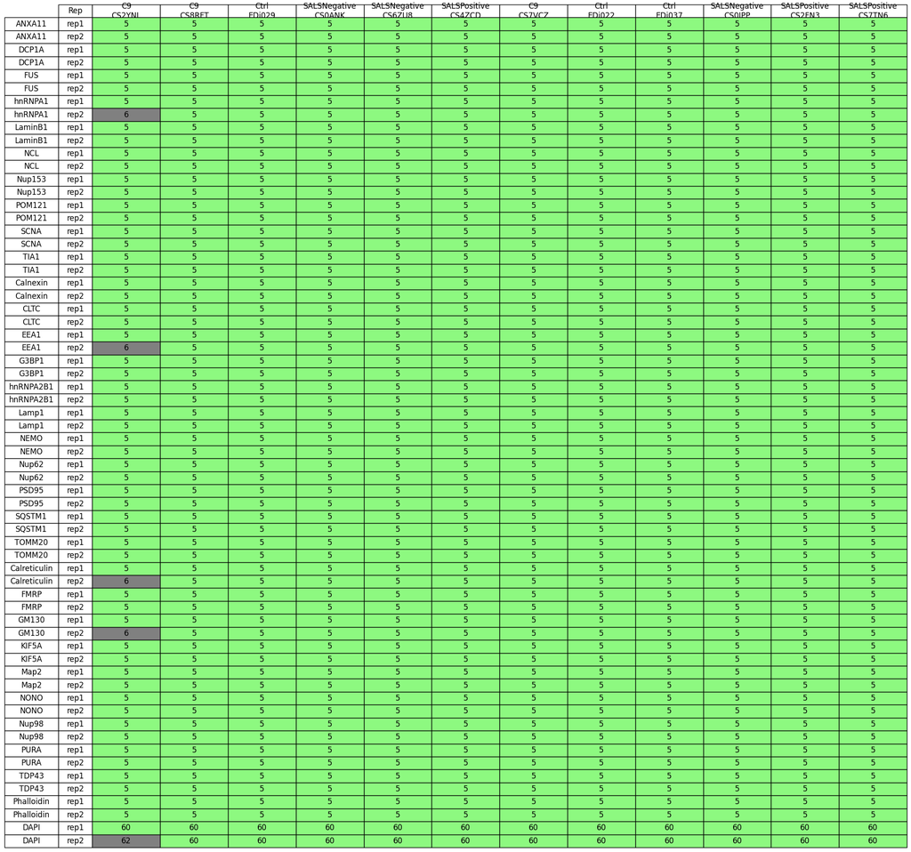

```python
procs = run_validate_folder_structure(root_directory_proc, True, AC_panels_new, AC_markers_new,None, AC_marker_info_new,
                                    AC_cell_lines_to_cond_new, AC_reps_new, AC_cell_lines_for_disp_new, AC_expected_dapi_raw_new,
                                     batches=batches, fig_width=8,expected_count=5, check_antibody=False)
```

### Difference between Raw and Processed

```
batch1
```

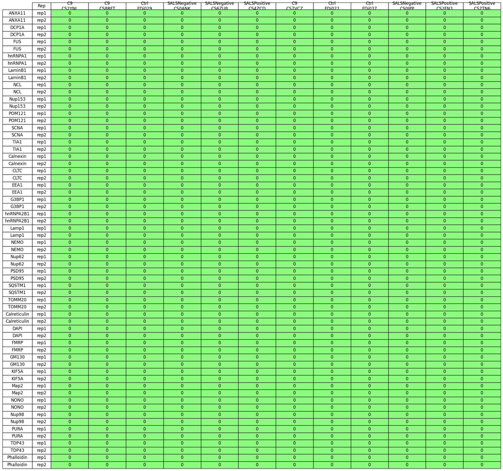

```python
display_diff(batches, raws, procs, None, fig_width=8)
```

### Variance in each batch (of processed files)

```python
for batch in batches:
    with contextlib.redirect_stdout(io.StringIO()):
        var = sample_and_calc_variance(root_directory_proc, batch,
                                       sample_size_per_markers=200, cond_count=1, rep_count=len(AC_reps_new),
                                       num_markers=len(AC_markers_new))
    print(f'{batch} var: ',var)
```

```
batch1 var:  0.033619241535540724
```

## Preprocessing Filtering qc

By order of filtering

### 1. % site survival after Brenner on DAPI channel

Percentage out of the total sites

```
NOT REALLY RELEVANT - RUNNING WITHOUT BRENNER!
```

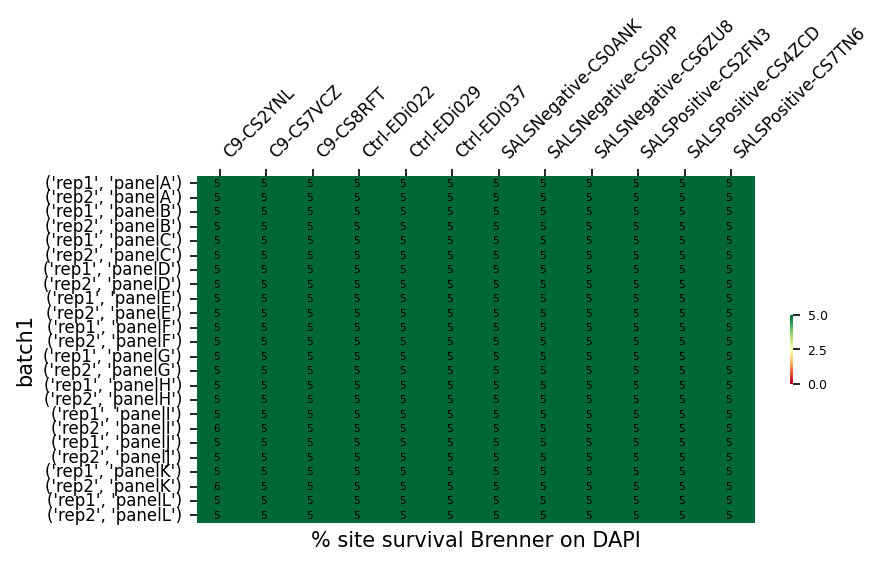

```python
print('NOT REALLY RELEVANT - RUNNING WITHOUT BRENNER!')
dapi_filter_by_brenner = show_site_survival_dapi_brenner(df_dapi,batches, AC_line_colors_new, AC_panels_new,
                                                        figsize=(6,3), reps=AC_reps_new, vmax=5)
```

### 2. % Site survival after Cellpose

Percentage out of the sites that passed the previous filter. In parenthesis are absolute values.

**A site will be filtered out if Cellpose found 0 cells in it.**

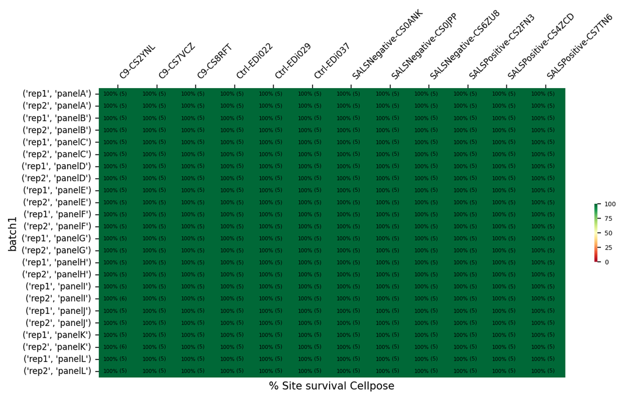

```python
dapi_filter_by_cellpose = show_site_survival_dapi_cellpose(df_dapi, batches, dapi_filter_by_brenner,
                                                           AC_line_colors_new, AC_panels_new, figsize=(10,5), reps=AC_reps_new)
```

### 3. % Site survival by tiling

Percentage out of the sites that passed the previous filter. In parenthesis are absolute values.

**A site will be filtered out if after tiling, no tile is containing at least 85% of a cell that Cellpose detected.**

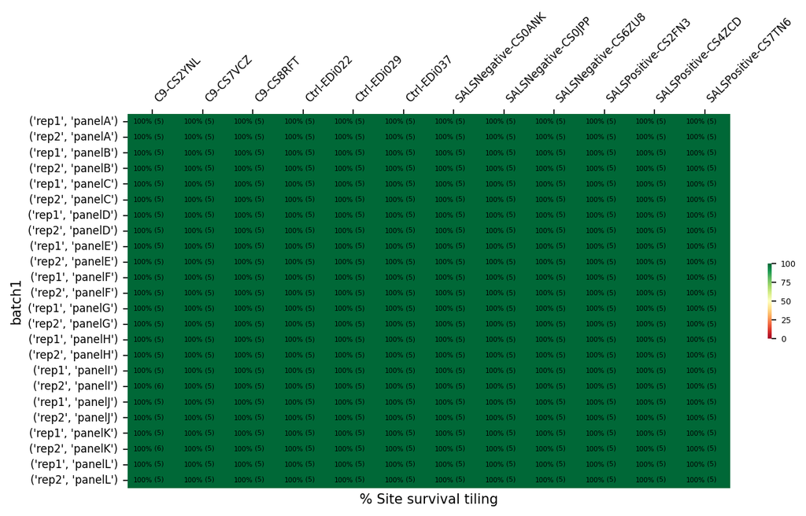

```python
dapi_filter_by_tiling=show_site_survival_dapi_tiling(df_dapi, batches, dapi_filter_by_cellpose,
                                                     AC_line_colors_new, AC_panels_new,figsize=(10,5), reps=AC_reps_new)
```